# DV_TableauProject2 - Crosstabs in Tableau and R using SQL

Jorge Paramo, Aldo Carranza, Kevin Nievera

Spring 2015

> *Summary*: In this project, we show how to make crosstabs in Tableau and in RStudio using R with SQL queries. The data used for this assignment is from a previous project on Life Expectancy by country.
- Data set can be found on the World Health Organization website
  - Life Expectancy: http://apps.who.int/gho/data/view.main.680

Required Packages: *jsonlite, RCurl, dplyr, knitr*

### Crosstab for Rank

> *Description*: In this crosstab, we show the countries, record year, and the rank of each year ordered by each country’s respective life expectancy during the recorded years.

```r
source("../01 SQL Crosstabs/rank.R", echo=FALSE)
```

#### Rank in R

```r
tbl_df(rank)
```

```
## Source: local data frame [582 x 3]
##
##        COUNTRY YEAR RANK
## 1  Afghanistan 1990    3
## 2  Afghanistan 2000    2
## 3  Afghanistan 2012    1
## 4      Albania 1990    3
## 5      Albania 2000    2
## 6      Albania 2012    1
## 7      Algeria 1990    3
## 8      Algeria 2000    2
## 9      Algeria 2012    1
## 10     Andorra 1990    3
## ..         ...  ...  ...
```

#### Rank in Tableau

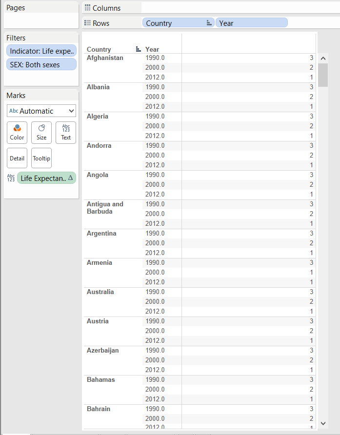

### Crosstab for Last_value/Max_value and Difference

> *Description*: In this crosstab, we show World Bank income groups, the countries belonging in those groups, the countries’ life expectancies in 2012, the maximum life expectancy along the pane, and the differences in life expectancy along the pane.

```r
source("../01 SQL Crosstabs/max_difference.R", echo=FALSE)
```

#### Last_value/Max_value and Difference in R

```r
tbl_df(max_difference)
```

```
## Source: local data frame [194 x 5]
##
##    INCOMEGROUP             COUNTRY LIFEYEARS MAX_LIFE DIFFERENCE_LIFE
## 1  High-income             Andorra        83       84               1
## 2  High-income Antigua and Barbuda        75       84               9
## 3  High-income           Australia        83       84               1
## 4  High-income             Austria        81       84               3
## 5  High-income             Bahamas        75       84               9
## 6  High-income             Bahrain        77       84               7
## 7  High-income            Barbados        78       84               6
## 8  High-income             Belgium        80       84               4
## 9  High-income   Brunei Darussalam        77       84               7
## 10 High-income              Canada        82       84               2
## ..         ...                 ...       ...      ...             ...
```

#### Last_value/Max_value and Difference in Tableau

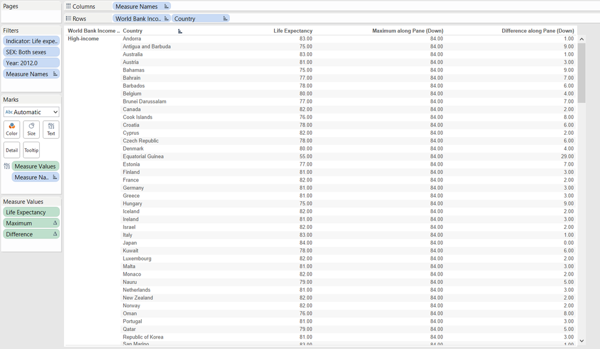

### Crosstab for Nth Value

```r
source("../01 SQL Crosstabs/nth_value.R", echo=FALSE)
```

#### Nth Value in R

```r
tbl_df(nth_value)
```

```
## Source: local data frame [582 x 3]
##
##        COUNTRY YEAR LIFE_EXPECT
## 1  Afghanistan 1990          55
## 2  Afghanistan 2000          55
## 3  Afghanistan 2012          55
## 4      Albania 1990          70
## 5      Albania 2000          70
## 6      Albania 2012          70
## 7      Algeria 1990          70
## 8      Algeria 2000          70
## 9      Algeria 2012          70
## 10     Andorra 1990          80
## ..         ...  ...         ...
```

#### Nth Value in Tableau

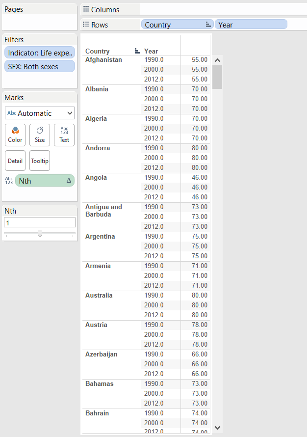

### Crosstab for Cumulative Distribution

> *Description*: This crosstab attempts to show the cumulative distribution of life expectancy for each country in each of the 6 World Health Organization Regions.

```r
source("../01 SQL Crosstabs/cume_dist.R", echo=FALSE)
```

#### Cumulative Distribution in R

```r
head(cume_dist)
```

```
##   WHOREGION      COUNTRY CUME_DIST
## 1    Africa      Algeria 0.9347826
## 2    Africa       Angola 0.1086956
## 3    Africa        Benin 0.5652174
## 4    Africa     Botswana 0.7173913
## 5    Africa Burkina Faso 0.4565217
## 6    Africa      Burundi 0.3043478
```

#### Cumulative Distribution

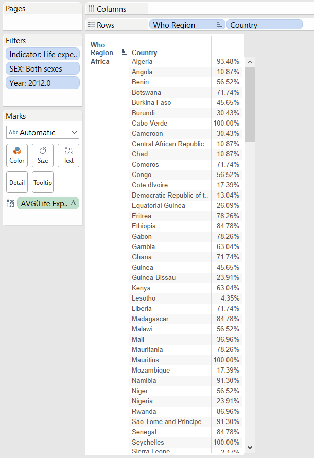